# ml_test - Wine Quality

- Show All Code
- Hide All Code
- View Source

Author

Iwo

# 1 Ładowanie bibliotek

```r
library("tidymodels")
library("AmesHousing")
library("skimr")
library("GGally")
library("vip")
library("patchwork")
library("tibble")
tidymodels_prefer()

set.seed(222)
```

# 2 Wczytanie i opis danych

Dane Wine Quality (UCI) dostępne są jako dwa pliki: `winequality-red.csv` i `winequality-white.csv`

Każdy rekord odpowiada jednemu winu i opisany jest zestawem cech numerycznych.

| Nazwa zmiennej | Opis | Jednostka / Zakres | Typ danych |
| --- | --- | --- | --- |
| **fixed acidity** | Zawartość kwasów stałych (głównie kwas winowy) | g/dm³ | numeryczna |
| **volatile acidity** | Kwasowość lotna (głównie kwas octowy); zbyt wysoka powoduje nieprzyjemny zapach | g/dm³ | numeryczna |
| **citric acid** | Zawartość kwasu cytrynowego – wpływa na świeżość i smak | g/dm³ | numeryczna |
| **residual sugar** | Cukier resztkowy po fermentacji | g/dm³ | numeryczna |
| **chlorides** | Ilość chlorków (zawartość soli) | g/dm³ | numeryczna |
| **free sulfur dioxide** | Wolny dwutlenek siarki – środek konserwujący | mg/dm³ | numeryczna |
| **total sulfur dioxide** | Całkowity dwutlenek siarki (wolny + związany) | mg/dm³ | numeryczna |
| **density** | Gęstość wina – zależy od zawartości cukru i alkoholu | g/cm³ | numeryczna |
| **pH** | Odczyn kwasowości – niższe wartości oznaczają bardziej kwaśne wino | 0–14 | numeryczna |
| **sulphates** | Zawartość siarczanów – wpływa na stabilność i smak | g/dm³ | numeryczna |
| **alcohol** | Zawartość alkoholu etylowego | % obj. | numeryczna |
| **quality** | Ocena jakości wina przez ekspertów | skala 0–10 (zazwyczaj 3–8) | numeryczna / kategoryczna |
| **type** | Typ wina – czerwone lub białe | `red` / `white` | kategoryczna |

Dane te pozwalają analizować, które cechy chemiczne najbardziej wpływają na ocenę jakości wina (`quality`).

```r
library(readr)

# download.file("https://archive.ics.uci.edu/ml/machine-learning-databases/wine-quality/winequality-red.csv", destfile = "winequality-red.csv")
# download.file("https://archive.ics.uci.edu/ml/machine-learning-databases/wine-quality/winequality-white.csv", destfile = "winequality-white.csv")

# separator = ";"
red  <- read_delim("winequality-red.csv", delim = ";", show_col_types = FALSE)
white <- read_delim("winequality-white.csv", delim = ";", show_col_types = FALSE)

red  <- red |> mutate(type = "red")
white <- white |> mutate(type = "white")

wine_raw <- red

dim(wine_raw)
```

```
[1] 1599   13
```

```r
skimr::skim(wine_raw)
```

Data summary

| Name | wine_raw |
| --- | --- |
| Number of rows | 1599 |
| Number of columns | 13 |
| _______________________ |  |
| Column type frequency: |  |
| character | 1 |
| numeric | 12 |
| ________________________ |  |
| Group variables | None |

**Variable type: character**

| skim_variable | n_missing | complete_rate | min | max | empty | n_unique | whitespace |
| --- | --- | --- | --- | --- | --- | --- | --- |
| type | 0 | 1 | 3 | 3 | 0 | 1 | 0 |

**Variable type: numeric**

| skim_variable | n_missing | complete_rate | mean | sd | p0 | p25 | p50 | p75 | p100 | hist |
| --- | --- | --- | --- | --- | --- | --- | --- | --- | --- | --- |
| fixed acidity | 0 | 1 | 8.32 | 1.74 | 4.60 | 7.10 | 7.90 | 9.20 | 15.90 | ▂▇▂▁▁ |
| volatile acidity | 0 | 1 | 0.53 | 0.18 | 0.12 | 0.39 | 0.52 | 0.64 | 1.58 | ▅▇▂▁▁ |
| citric acid | 0 | 1 | 0.27 | 0.19 | 0.00 | 0.09 | 0.26 | 0.42 | 1.00 | ▇▆▅▁▁ |
| residual sugar | 0 | 1 | 2.54 | 1.41 | 0.90 | 1.90 | 2.20 | 2.60 | 15.50 | ▇▁▁▁▁ |
| chlorides | 0 | 1 | 0.09 | 0.05 | 0.01 | 0.07 | 0.08 | 0.09 | 0.61 | ▇▁▁▁▁ |
| free sulfur dioxide | 0 | 1 | 15.87 | 10.46 | 1.00 | 7.00 | 14.00 | 21.00 | 72.00 | ▇▅▁▁▁ |
| total sulfur dioxide | 0 | 1 | 46.47 | 32.90 | 6.00 | 22.00 | 38.00 | 62.00 | 289.00 | ▇▂▁▁▁ |
| density | 0 | 1 | 1.00 | 0.00 | 0.99 | 1.00 | 1.00 | 1.00 | 1.00 | ▁▃▇▂▁ |
| pH | 0 | 1 | 3.31 | 0.15 | 2.74 | 3.21 | 3.31 | 3.40 | 4.01 | ▁▅▇▂▁ |
| sulphates | 0 | 1 | 0.66 | 0.17 | 0.33 | 0.55 | 0.62 | 0.73 | 2.00 | ▇▅▁▁▁ |
| alcohol | 0 | 1 | 10.42 | 1.07 | 8.40 | 9.50 | 10.20 | 11.10 | 14.90 | ▇▇▃▁▁ |
| quality | 0 | 1 | 5.64 | 0.81 | 3.00 | 5.00 | 6.00 | 6.00 | 8.00 | ▁▇▇▂▁ |

# 3 Cel

Celem analizy jest zrozumienie, które cechy chemiczne wpływają na ocenę jakości wina. Zmienna celu to `quality` — ocena sensoryczna w skali całkowitej. Możemy traktować ją jako regresję (ciągła przybliżona) lub jako problem klasyfikacji/porządkowy.

```r
wine_raw |> select(quality) |> skimr::skim()
```

Data summary

| Name | select(wine_raw, quality) |
| --- | --- |
| Number of rows | 1599 |
| Number of columns | 1 |
| _______________________ |  |
| Column type frequency: |  |
| numeric | 1 |
| ________________________ |  |
| Group variables | None |

**Variable type: numeric**

| skim_variable | n_missing | complete_rate | mean | sd | p0 | p25 | p50 | p75 | p100 | hist |
| --- | --- | --- | --- | --- | --- | --- | --- | --- | --- | --- |
| quality | 0 | 1 | 5.64 | 0.81 | 3 | 5 | 6 | 6 | 8 | ▁▇▇▂▁ |

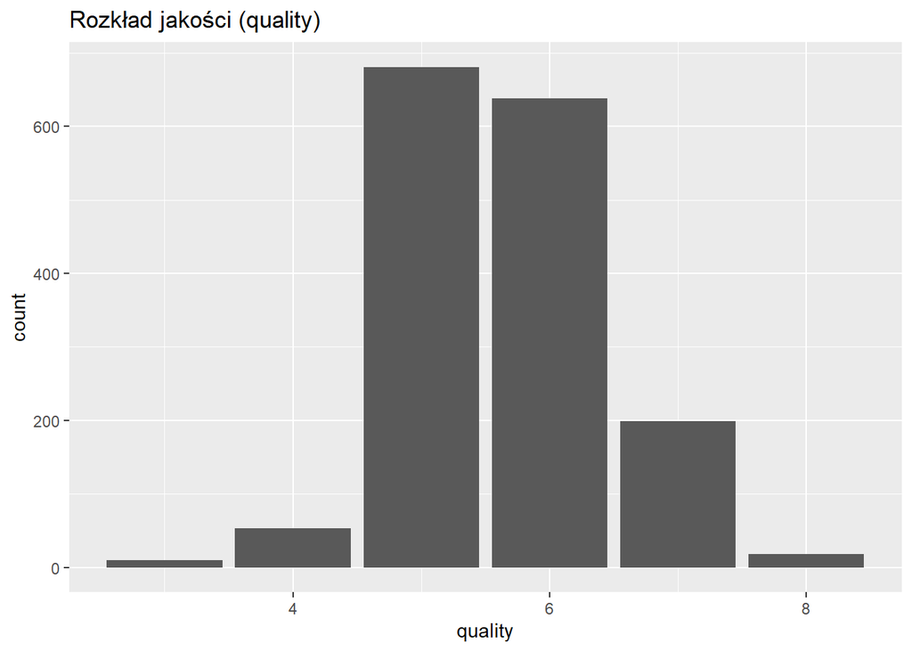

```r
# rozkład jakości
library(ggplot2)
ggplot(wine_raw, aes(quality)) + geom_bar() + ggtitle("Rozkład jakości (quality)")
```

# 4 Wstępna eksploracja

Szybkie wykresy i korelacje z `quality`.

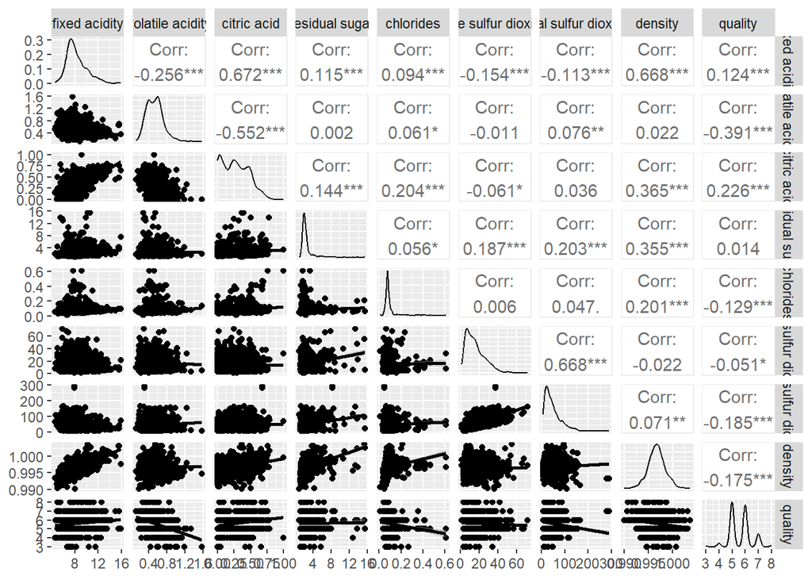

```r
num_vars <- wine_raw |> select(where(is.numeric)) |> names()
sel <- c(num_vars[1:8], "quality")

GGally::ggpairs(wine_raw |> select(all_of(sel)) |> na.omit(), lower = list(continuous = "smooth"))
```

```r
cors <- wine_raw |> select(where(is.numeric)) |> cor(use = "pairwise.complete.obs")
q_cor <- data.frame(
  feature = rownames(cors),
  correlation = cors[, "quality"]
)
q_cor |> arrange(desc(abs(correlation))) |> slice(1:10)
```

```
                                  feature correlation
quality                           quality  1.00000000
alcohol                           alcohol  0.47616632
volatile acidity         volatile acidity -0.39055778
sulphates                       sulphates  0.25139708
citric acid                   citric acid  0.22637251
total sulfur dioxide total sulfur dioxide -0.18510029
density                           density -0.17491923
chlorides                       chlorides -0.12890656
fixed acidity               fixed acidity  0.12405165
pH                                     pH -0.05773139
```

- **`alcohol`** ma **najsilniejszą dodatnią korelację** z jakością wina – im wyższa zawartość alkoholu, tym wino jest zwykle lepiej oceniane.
- **`volatile acidity`** wykazuje **umiarkowaną ujemną korelację** – większa kwasowość lotna (np. kwas octowy) obniża ocenę wina.
- **`pH`** jest praktycznie niepowiązane z oceną jakości.

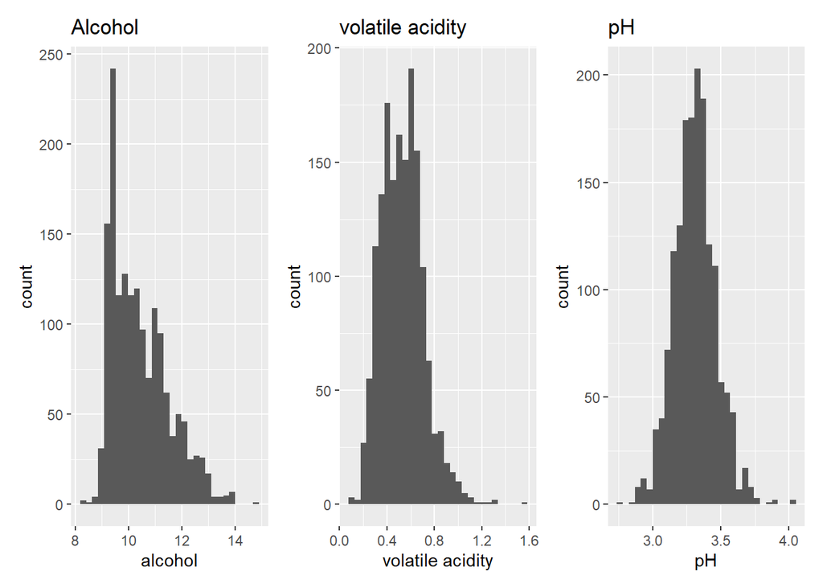

```r
p1 <- ggplot(wine_raw, aes(alcohol)) + geom_histogram(bins=30) + ggtitle("Alcohol")
p2 <- ggplot(wine_raw, aes(.data[['volatile acidity']])) + geom_histogram(bins=30) + ggtitle("volatile acidity")
p3 <- ggplot(wine_raw, aes(pH)) + geom_histogram(bins=30) + ggtitle("pH")

p1 + p2 + p3
```

# 5 Podział na zbiór treningowy i testowy

Dane zostały podzielone w proporcji **80% / 20%** na zbiór treningowy i testowy z użyciem stratyfikacji względem zmiennej `quality`. Dzięki temu rozkład jakości pozostaje podobny w obu zbiorach, co zwiększa wiarygodność oceny modelu.

```r
split <- initial_split(wine_raw, prop = 0.8, strata = quality)
train_tbl <- training(split)
test_tbl  <- testing(split)

nrow(train_tbl)
```

```
[1] 1278
```

```r
nrow(test_tbl)
```

```
[1] 321
```

# 6 Receptura

Plan receptury:

```r
library(recipes)

wine_recipe <- recipe(quality ~ ., data = train_tbl) |>
  # jeśli łączysz oba zbiory, type jest nominalne — w przeciwnym razie ten krok nic nie robi
  step_impute_median(all_numeric_predictors()) |>
  step_nzv(all_predictors()) |>
  step_normalize(all_numeric_predictors())

summary(wine_recipe)
```

```
# A tibble: 13 × 4
   variable             type      role      source
   <chr>                <list>    <chr>     <chr>
 1 fixed acidity        <chr [2]> predictor original
 2 volatile acidity     <chr [2]> predictor original
 3 citric acid          <chr [2]> predictor original
 4 residual sugar       <chr [2]> predictor original
 5 chlorides            <chr [2]> predictor original
 6 free sulfur dioxide  <chr [2]> predictor original
 7 total sulfur dioxide <chr [2]> predictor original
 8 density              <chr [2]> predictor original
 9 pH                   <chr [2]> predictor original
10 sulphates            <chr [2]> predictor original
11 alcohol              <chr [2]> predictor original
12 type                 <chr [3]> predictor original
13 quality              <chr [2]> outcome   original
```

# 7 Specyfikacje modeli

W tej części definiujemy cztery różne podejścia do regresji jakości wina. Każdy model wykorzystuje inne założenia i metody regularyzacji lub uogólnienia.

- Regresja liniowa (OLS) – prosta baza porównawcza.
- GLMNet – regresja liniowa z regularyzacją L1/L2 (ridge / lasso).
- Random Forest (ranger) – model drzew losowych, dobrze radzi sobie z nieliniowościami.
- XGBoost – wydajny model boostingowy, bardzo skuteczny.

```r
# 1. Linear regression (OLS)
lm_spec <- linear_reg() |>
  set_engine("lm", importance = "impurity") |>
  set_mode("regression")

# 2. Regularized (glmnet)
glmnet_spec <- linear_reg(penalty = tune(), mixture = tune()) |>
  set_engine("glmnet", importance = "impurity")

# 3. Random forest (ranger)
rf_spec <- rand_forest(mtry = tune(), trees = 1000, min_n = tune()) |>
  set_engine("ranger", importance = "impurity") |>
  set_mode("regression")

# 4. Gradient boosting (xgboost)
xgb_spec <- boost_tree(trees = tune(), tree_depth = tune(), learn_rate = tune(), loss_reduction = tune(), sample_size = tune()) |>
  set_engine("xgboost") |>
  set_mode("regression")
```

# 8 Workflow

Workflow on wcześniej zdefiniowaną recepturę (`wine_recipe`) z wybranym modelem uczenia maszynowego, dzięki czemu cały proces przygotowania danych i trenowania odbywa się w jednej strukturze.

```r
library(workflows)

wf_lm <- workflow() |> add_recipe(wine_recipe) |> add_model(lm_spec)
wf_glmnet <- workflow() |> add_recipe(wine_recipe) |> add_model(glmnet_spec)
wf_rf <- workflow() |> add_recipe(wine_recipe) |> add_model(rf_spec)
wf_xgb <- workflow() |> add_recipe(wine_recipe) |> add_model(xgb_spec)
```

# 9 Walidacja krzyżowa i plan strojenia

Tworzony jest plan walidacji krzyżowej (5-fold CV), który pozwala ocenić modele na różnych podzbiorach danych.

Dodatkowo określane są zakresy hiperparametrów i siatki (grid) dla każdego modelu, które zostaną użyte w procesie strojenia.

```r
library(dials)
library(rsample)

cv_splits <- vfold_cv(train_tbl, v = 5, strata = quality)

glmnet_params <- parameters(penalty(), mixture())
rf_params <- parameters(
  mtry(range = c(1, floor(sqrt(ncol(train_tbl)-1)))),
  min_n()
)

xgb_params <- parameters(
  tree_depth(),
  trees(),
  learn_rate(),
  loss_reduction(),
  sample_size = sample_prop(range = c(0.5, 1.0))
)

xgb_params_final <- finalize(xgb_params, train_tbl)

# Create grids
glmnet_grid <- grid_regular(glmnet_params, levels = 5)
rf_grid <- grid_random(rf_params, size = 20)
xgb_grid <- grid_random(xgb_params_final, size = 20)
```

# 10 Strojenie modeli (tuning)

Tutaj każdy model jest strojeny (tuningowany) przy użyciu wcześniej zdefiniowanej walidacji i siatek parametrów. Wyniki oceniamy na podstawie trzech metryk: RMSE, R² i MAE.

```r
library(tune)
library(glmnet)
library(xgboost)
library(ranger)

reg_metrics <- metric_set(rmse, rsq, mae)

# GLMnet
glmnet_res <- tune_grid(
  wf_glmnet,
  resamples = cv_splits,
  grid = glmnet_grid,
  metrics = reg_metrics,
  control = control_grid(save_pred = FALSE, verbose = TRUE)
)

collect_metrics(glmnet_res)
```

```
# A tibble: 75 × 8
        penalty mixture .metric .estimator  mean     n std_err .config
          <dbl>   <dbl> <chr>   <chr>      <dbl> <int>   <dbl> <chr>
 1 0.0000000001    0    mae     standard   0.500     5  0.0109 pre0_mod01_post0
 2 0.0000000001    0    rmse    standard   0.645     5  0.0148 pre0_mod01_post0
 3 0.0000000001    0    rsq     standard   0.353     5  0.0220 pre0_mod01_post0
 4 0.0000000001    0.25 mae     standard   0.499     5  0.0108 pre0_mod02_post0
 5 0.0000000001    0.25 rmse    standard   0.645     5  0.0146 pre0_mod02_post0
 6 0.0000000001    0.25 rsq     standard   0.352     5  0.0221 pre0_mod02_post0
 7 0.0000000001    0.5  mae     standard   0.499     5  0.0108 pre0_mod03_post0
 8 0.0000000001    0.5  rmse    standard   0.645     5  0.0146 pre0_mod03_post0
 9 0.0000000001    0.5  rsq     standard   0.352     5  0.0221 pre0_mod03_post0
10 0.0000000001    0.75 mae     standard   0.499     5  0.0108 pre0_mod04_post0
# ℹ 65 more rows
```

```r
# Random Forest
rf_res <- tune_grid(
  wf_rf,
  resamples = cv_splits,
  grid = rf_grid,
  metrics = reg_metrics,
  control = control_grid(verbose = TRUE)
)
collect_metrics(rf_res)
```

```
# A tibble: 57 × 8
    mtry min_n .metric .estimator  mean     n std_err .config
   <int> <int> <chr>   <chr>      <dbl> <int>   <dbl> <chr>
 1     1     3 mae     standard   0.443     5  0.0148 pre0_mod01_post0
 2     1     3 rmse    standard   0.590     5  0.0211 pre0_mod01_post0
 3     1     3 rsq     standard   0.475     5  0.0306 pre0_mod01_post0
 4     1    11 mae     standard   0.464     5  0.0133 pre0_mod02_post0
 5     1    11 rmse    standard   0.604     5  0.0201 pre0_mod02_post0
 6     1    11 rsq     standard   0.455     5  0.0301 pre0_mod02_post0
 7     1    13 mae     standard   0.468     5  0.0132 pre0_mod03_post0
 8     1    13 rmse    standard   0.607     5  0.0203 pre0_mod03_post0
 9     1    13 rsq     standard   0.451     5  0.0305 pre0_mod03_post0
10     1    15 mae     standard   0.472     5  0.0128 pre0_mod04_post0
# ℹ 47 more rows
```

```r
# XGBoost
xgb_res <- tune_grid(
  wf_xgb,
  resamples = cv_splits,
  grid = xgb_grid,
  metrics = reg_metrics,
  control = control_grid(verbose = TRUE)
)
collect_metrics(xgb_res)
```

```
# A tibble: 60 × 11
   trees tree_depth    learn_rate loss_reduction sample_size .metric .estimator
   <int>      <int>         <dbl>          <dbl>       <dbl> <chr>   <chr>
 1    55         15 0.00000000156       5.76e- 9       0.547 mae     standard
 2    55         15 0.00000000156       5.76e- 9       0.547 rmse    standard
 3    55         15 0.00000000156       5.76e- 9       0.547 rsq     standard
 4   104          5 0.000000138         8.31e- 7       0.758 mae     standard
 5   104          5 0.000000138         8.31e- 7       0.758 rmse    standard
 6   104          5 0.000000138         8.31e- 7       0.758 rsq     standard
 7   286          8 0.00381             1.14e- 8       0.736 mae     standard
 8   286          8 0.00381             1.14e- 8       0.736 rmse    standard
 9   286          8 0.00381             1.14e- 8       0.736 rsq     standard
10   320          7 0.00776             1.27e-10       0.637 mae     standard
# ℹ 50 more rows
# ℹ 4 more variables: mean <dbl>, n <int>, std_err <dbl>, .config <chr>
```

# 11 Porównanie model - wybór najlepszych parametrów i finalny fit

Na podstawie wyników walidacji wybierane są najlepsze hiperparametry (według RMSE), a następnie model jest trenowany ponownie na całym zbiorze treningowym i oceniany na zbiorze testowym.

Zbierzemy wyniki dla wszystkich modeli i porównamy RMSE oraz R^2.

```r
best_rf <- select_best(rf_res, metric = "rmse")
best_glmnet <- select_best(glmnet_res, metric = "rmse")
best_xgb <- select_best(xgb_res, metric = "rmse")

final_rf <- finalize_workflow(wf_rf, best_rf)
final_glmnet <- finalize_workflow(wf_glmnet, best_glmnet)
final_xgb <- finalize_workflow(wf_xgb, best_xgb)

fit_rf <- fit(final_rf, data = train_tbl)
fit_glmnet <- fit(final_glmnet, data = train_tbl)
fit_xgb <- fit(final_xgb, data = train_tbl)
fit_lm <- fit(wf_lm, data = train_tbl)

evaluate_on_test <- function(fit_wf, test_data){
  pred <- predict(fit_wf, test_data) |> bind_cols(test_data |> select(quality))
  tibble(rmse = yardstick::rmse_vec(truth = pred$quality, estimate = pred$.pred),
         rsq  = yardstick::rsq_vec(truth = pred$quality, estimate = pred$.pred))
}

res_rf <- evaluate_on_test(fit_rf, test_tbl)
res_glmnet <- evaluate_on_test(fit_glmnet, test_tbl)
res_xgb <- evaluate_on_test(fit_xgb, test_tbl)
res_lm <- evaluate_on_test(fit_lm, test_tbl)

bind_rows(lm = res_lm, glmnet = res_glmnet, rf = res_rf, xgb = res_xgb, .id = "model")
```

```
# A tibble: 4 × 3
  model   rmse   rsq
  <chr>  <dbl> <dbl>
1 lm     0.685 0.346
2 glmnet 0.685 0.347
3 rf     0.607 0.496
4 xgb    0.585 0.522
```

| Model | RMSE | R² |
| --- | --- | --- |
| **Regresja liniowa (lm)** | 0.685 | 0.346 |
| **GLMNet** | 0.685 | 0.347 |
| **Random Forest (rf)** | 0.607 | 0.496 |
| **XGBoost (xgb)** | 0.585 | 0.522 |

Modele nieliniowe (**Random Forest** i **XGBoost**) osiągnęły wyraźnie lepsze wyniki niż proste modele liniowe.  
Najniższy błąd RMSE (0.585) oraz najwyższy współczynnik determinacji R² (0.522) uzyskał **model XGBoost**, co wskazuje na jego największą zdolność do odwzorowania zależności między cechami chemicznymi a oceną jakości wina.

# 12 Interpretowalność: ważność cech

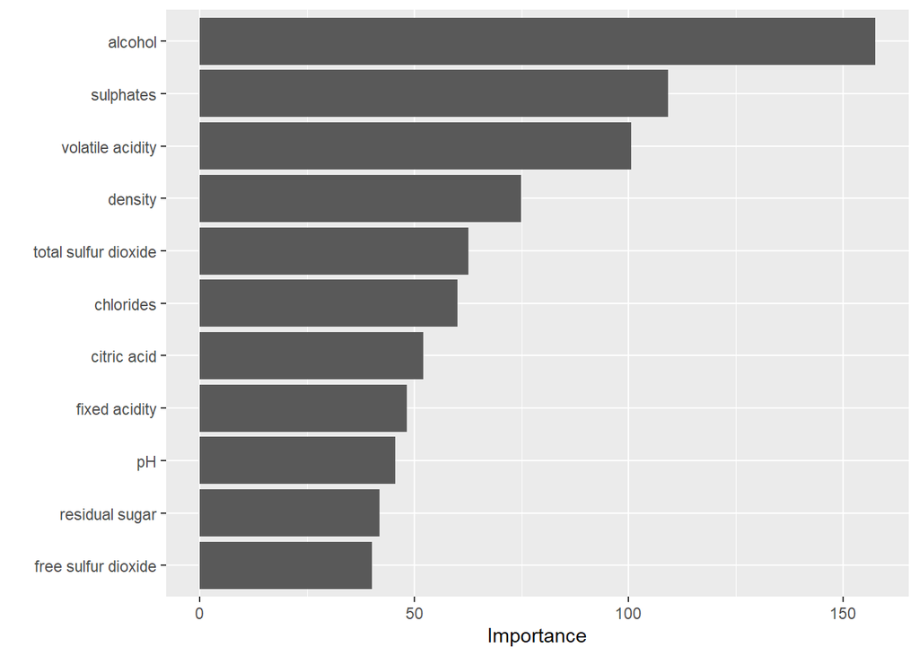

```r
fit_rf |>
  pull_workflow_fit() |>
  vip::vip(num_features = 15)
```

Oznacza to, że wina o wyższej zawartości alkoholu i umiarkowanej kwasowości są oceniane jako lepsze.

# 13 Wnioski